# Assignment One Data Analysis

Stafford

21/01/2020

# Using Markdown - Species Limbs Data

## Initializing Data

Before inputting any data I ran the libraries for all the packages I was going to use in this document.

Data was transfered from last weeks assignments as a .csv file “measurements.csv”. to simplify writing and observing the script, Names of the varibles were changed to three letter acronyms.

As the initial data had differing units of cm and mm, an “if” statement was used to change the dimesions to all be in centimeters (cm) and corresponding units were simply changed to cm.

Volume was then calculated using the equation for volume of a cylinder - $V=(\pi*r^2)*h$ - to be used in the fallowing Figures.

## Species limb Dimensions Plot

ggplot2 was used to create a scatter plot specified by the geom "_point“. To keep the graph nice and clean I added the theme”classic" as well as simple titles using “ggtitle” and “labs”/

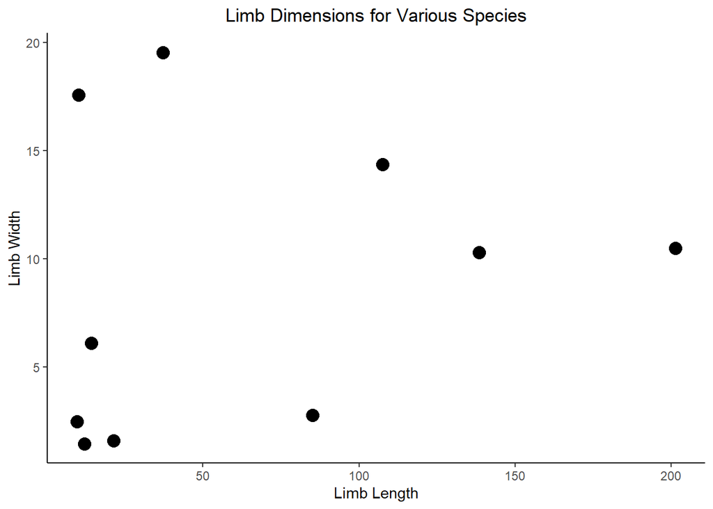

Figure 1. Scatter plot comparing ten different species based on their limb lengths (x axis) and limb widths (y axis), species depicted as individual points.

## Above Average Species Plot

To create a graph of the above average volumes I first calculated the mean volume and set it as its own object. fallowing this I created a seperate data.frame that only included volumes greater then the mean.

A similar ggplot was used to maintain consistancy throughout report. The only differences are the values used and the title name.

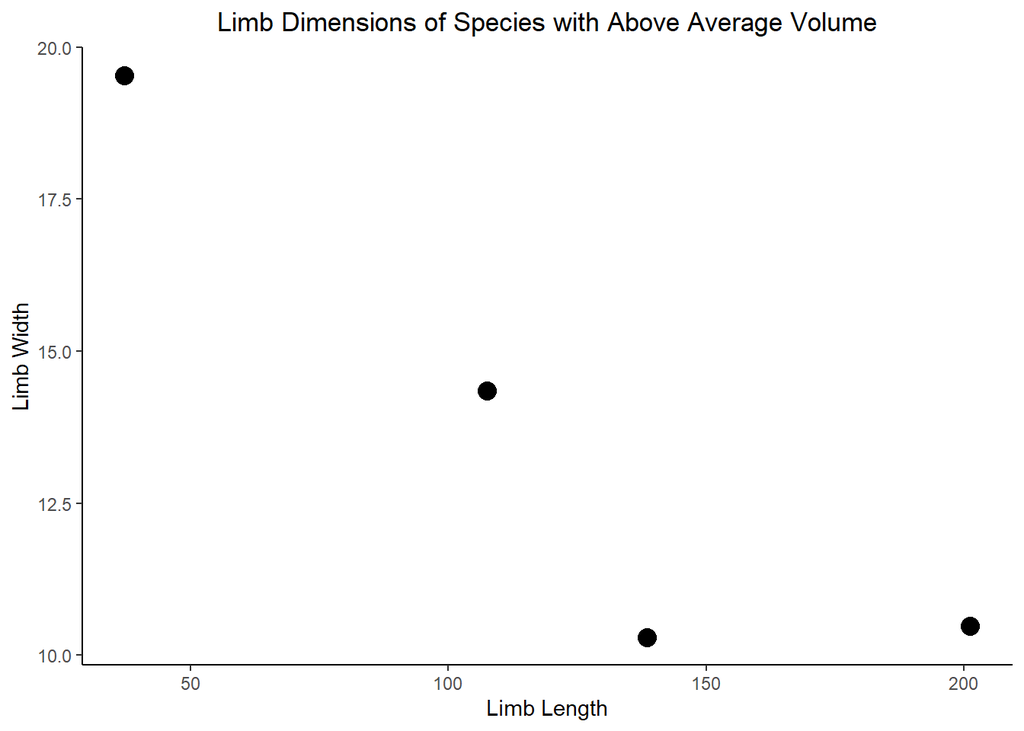

Figure 2. Scatter plot of a species in Figure 1 with above average limb volumes, shown as their relationship between limb legth (x axis) and limb width (y axis). Species shown as individual points.

## Below Average Species and Their Volumes

A table of the species and their corresponding volumes was created using the “kable” function. Before I could do this I first subsetted the data using the “filter” function by selecting volumes of which were below the previously calculated mean.

This subset was then narrowed down into a data.frame or matrix that only included the species and volumes wanted for this table. Finally the volumes were rounded to two decimal points and computed using the “kable” function.

Table 1: Name and limb volumes of species with below average limb volumes

| Species | Volume |
| --- | --- |
| Pan paniscus | 46.46 |
| Elephas maximus indicus | 19.78 |
| Ursus arctos | 2449.48 |
| Dermochelys coriacea | 417.93 |
| Panthera onca | 42.31 |
| Mustela nigripes | 507.00 |

## Eyes: Relationship Between Number of Eyes and Limb Dimensions

- Disclaimer - As it is very difficult to actually count the number of eyes on each species, a random number of eyes was asigned to them. I believe this provides an accurate depiction of the number of eyes found on each species.

A random binomial distribution with a set seed was used to assign number of eyes to each species using the “set.seed” and “rbinom” functions,

Finally, the species were grouped by their number of eyes and an summary of average and standard deviations of the groups limb dimensions was created. Again, rounding to two decimal places, another table was made using the “kable” function.

Table 2: Average (Avg) and Standard Deviation (SD) of Volume, Length, and Width for Species with Zero, One, and Two Eyes

| Eyes | Volume_Avg | Volume_SD | Length_Avg | Length_SD | Width_Avg | Width_SD |
| --- | --- | --- | --- | --- | --- | --- |
| 0 | 4675.78 | 6057.50 | 52.75 | 74.24 | 10.11 | 7.55 |
| 1 | 7063.47 | 9414.32 | 85.43 | 76.50 | 6.12 | 5.92 |
| 2 | 5781.87 | 7585.76 | 25.73 | 16.18 | 12.82 | 9.50 |